# Lecture #1: Models and Functions; Rates of Change

MATH 145 – Calculus I

Torin Quinlivan

tquinlivan@knox.edu

Knox College

August 23, 2025

## What is Calculus?

Calculus is, at its core, about how changing quantities relate to each other.

Algebra can be thought of as the study of arithmetic operations, and how they relate to each other.

Geometry can be thought of as the study of space; of lines and shapes.

Calculus is the study of change, particularly continuous change.

Today we will try to develop the mathematical vocabulary to explore this idea.

## Motivating Example

Consider a tank in the shape of an inverted circular cone (point down) where the tank’s radius is 2 feet and its depth is 4 feet. Suppose that the tank is being filled with water that is at a constant rate of 0.75 cubic feet per minute.

1. What can we say about the relationship between the height and the radius of the water?
2. What about the relationship between the height and the volume of the water?
3. What about the radius and the volume?

## Relationships and Functions

Sometimes one quantity *depends* on another quantity in a deterministic way, as seen by:

**A table of values:**

[output not shown]

## Relationships and Functions

**A graph:**

[figure not shown]

## Relationships and Functions

**A function formula:**

$$V(h) = \frac{\pi}{12} h^3$$
$$V(2) = \left( \frac{\pi}{12} \right) 2^3 = \frac{8 \pi}{12} = \frac{2 \pi}{3}$$

Understanding a relationship between quantities in detail often involves a function formula. Get used to these!

## What is a Function?

A **function** is a process that may be applied to a collection of input values to produce a corresponding collection of output values in such a way that the process produces one and only one output value for any single input value.

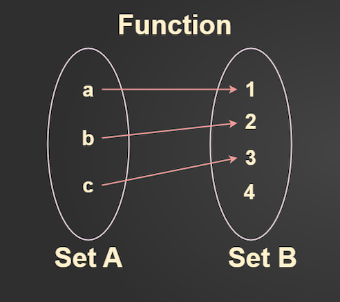

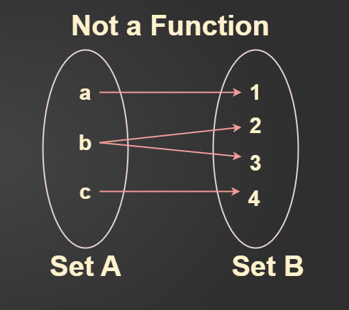

## What is a Function?

**Note:** A function can be presented in different ways, and still be the same function.

For example, all of the following are describe the sine function:
$$\begin{gather*}
f(x) = \sin(x) \\[0.2em]
f(x) = \tan(x) \cos(x) \\[0.2em]
f(x) = x - \frac{x^3}{3!} + \frac{x^5}{5!} - \frac{x^7}{7!} + \dots \\[0.2em]
f(x) = \frac{e^{i x} - e^{-i x}}{2i} \\[0.2em]
f(x) = -i\sinh(ix)
\end{gather*}$$

## Domain, Codomain and Range

Let $F : A \rightarrow B$.

The set $A$ of possible inputs to $F$ is called the **domain** of $F$.

The set $B$ of potential outputs from $F$ is called the **codomain** of $F$.

The **range** of $F$ is the collection of all actual outputs of the function.That is, the range is the collection of all elements $y \in B$ for which it is possible to find an element $x \in A$ such that $F(x) = y$.

## Example: Domain, Codomain and Range

Identify the domain, codomain and range in the following examples:

1. Let $f : \mathbb{R} \rightarrow \mathbb{R}$ where $f(x) = x^2$.
2. A researcher predicts the height (in inches) of adult males with their height (in inches) at age 3, using the formula $h(x) = 2.6x + 6.8$.

## What does that mean in English?

The **domain** is the set of numbers that can be entered into the function.

The **codomain** is the set of numbers that can come out of the function, in the function definition.

The **range** is the set of numbers that can actually come out of the function.

A value $y$ can be in the codomain and not in the range, if there is no value $x$ in the domain that when put into the function will ever output $y$.

## Vertical Line Test

**WARNING!** Not every graph is a function. A function must satisfy the **vertical line test**. If you draw a vertical line anywhere on the graph, if the line ever crosses the graph in more than one place, then it is not a function.

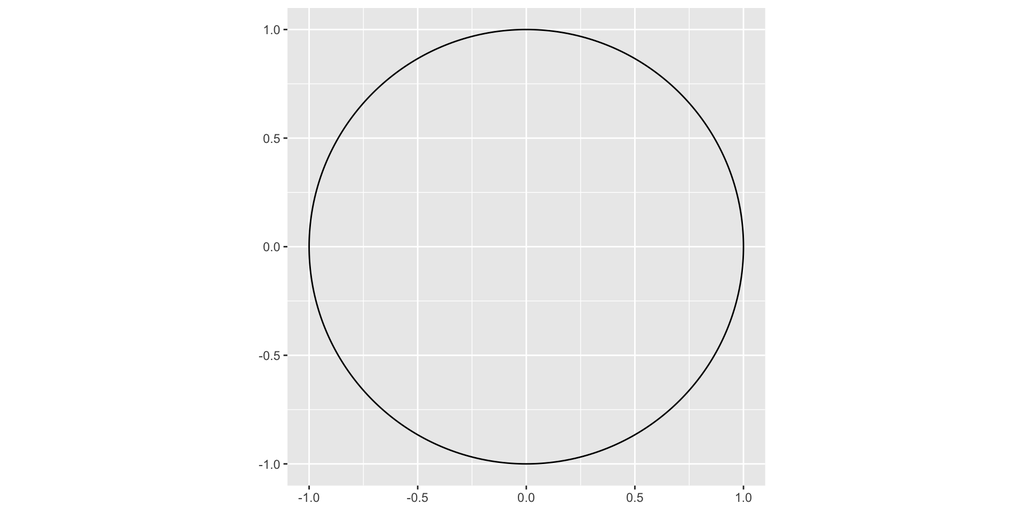

Figure 1: Not a Function!

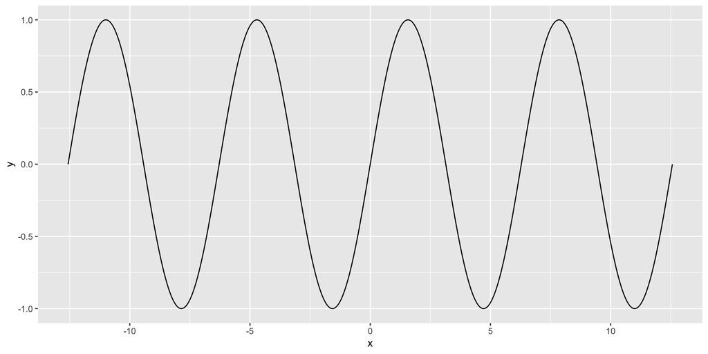

Figure 2: A Function

## Functions and Models

A **mathematical model** is an abstract concept through which we use mathematical language and notation to describe a phenomenon in the world around us.

Often a mathematical model is just a function formula, paying attention to the domain, range, etc.

## Mathematical Model Example

Consider our example with the tank in the shape of a cone.

$$\begin{gather*}
V_1(h) = \frac{\pi}{12} h^3, \qquad 0 \le h \le 4 \\[1em]
V_2(r) = \frac{2}{3} \pi r^3, \qquad r \in [0, 2]
\end{gather*}$$

## Functions and Rates of Change

For a function $f$ defined on an interval $[a, b]$, the **average rate of change** of $f$ on $[a, b]$ is the quantity:

$$AV_{[a, b]} = \frac{f(b) - f(a)} {b - a}$$

Note that this is the change of the graph in the $y$-direction over the change of the graph in the $x$-direction, $\dfrac{\Delta y}{\Delta x}$.

## Rates of Change Example

1. What is the average rate of change of $V$ over [0, 1]?
2. What is the average rate of change of $V$ over [0, 2]?
3. What is the average rate of change of $V$ over [0, 0.5]?

## Rates of Change and the Shape of a Function

Let $f$ be a function defined on an interval $(a, b)$ (that is, on the set of all $x$ for which $a < x < b$).

We say that $f$ is **increasing on $(a, b)$** provided that the function is always rising as we move from left to right. That is, for any $x$ and $y$ in $(a, b)$, if $x < y$, the $f(x) < f(y)$.

We say that $f$ is **decreasing on $(a, b)$** provided that the function is always falling as we move from left to right. That is, for any $x$ and $y$ in $(a, b)$, if $x < y$, the $f(x) > f(y)$.

Rates of change (but not *average* rates of change) can be used to tell if a function is increasing or decreasing on an interval.